# Climate Variables

E Holmes

April 22, 2025

```r
library(tidyverse)
options(dplyr.summarise.inform = FALSE)
```

## Climate Indices

See also https://psl.noaa.gov/data/atmoswrit/corr/timeseries/ and https://psl.noaa.gov/data/climateindices/list/.

I have created a dataset of seasonal climate variables from the PSL page.

Variables:

| Index | Region | Influences on Salmon | Notes |
| --- | --- | --- | --- |
| **PDO** (Pacific Decadal Oscillation) | North Pacific | Ocean productivity, survival of juveniles | Warm phase reduces survival in Alaska, improves in CA. |
| **ONI** (Oceanic Niño Index) | Equatorial Pacific (global effects) | Marine heatwaves, prey availability | El Niño years generally reduce survival along West Coast. |
| **MEIv2** (Multivariate ENSO Index) | Equatorial Pacific/global | Similar to ONI but broader; marine habitat stress | Integrated index of ENSO variability; affects productivity. |
| **PNA** (Pacific-North American Pattern) | North America and North Pacific | River flows, snowpack, freshwater survival | Positive PNA linked to warmer/drier winters, lower survival. |
| **EPO** (East Pacific Oscillation) | Eastern North Pacific | Winter ocean conditions | Negative EPO can improve early marine survival conditions. |
| **WP** (Western Pacific Pattern) | Western Pacific, Eastern Asia | Atmospheric circulation affecting ocean entry timing | Alters timing and success of smolt outmigration indirectly. |
| **CENSO** (Central ENSO Index) | Central Pacific | Central Pacific ENSO variability | May modulate effects of traditional El Niño on survival. |
| **WHWP** (Western Hemisphere Warm Pool) | Atlantic and Eastern Pacific | Hurricane activity (Atlantic) | Not directly linked to salmon survival in the North Pacific. |
| **IPOTPI** (Indo-Pacific Ocean Temperature Pattern Index) | Indo-Pacific | Tropical SST variability patterns | Emerging index; indirect possible link to broad-scale climate affecting salmon. |
| **NP** (North Pacific Index) | North Pacific | Aleutian Low strength, ocean upwelling | Strong Aleutian Low (lower NP) → better salmon survival. |
| **PACWARM** (Pacific Warm Pool Index) | Equatorial Pacific | Warm pool expansion influencing ENSO events | Can modulate strength of El Niño impacts on marine survival. |
| **GMSST** (Global Mean Sea Surface Temperature) | Global Ocean | Baseline warming trend | Higher GMSST linked to long-term habitat stress. |

## Loading data

I have created a data frame of North Pacific climate variables from NOAA PSL. Update your atsalibrary to version 1.6 to get the climate data or load `np_climate.RData` from the `Data_Images` directory.

```r
library(atsalibrary)
data("np_climate")
# this has seasonal and annual averages
# use ?np_climate for info
colnames(np_climate_month)
```

```
##  [1] "date"    "year"    "month"   "pna"     "epo"     "wp"      "censo"
##  [8] "whwp"    "oni"     "meiv2"   "pdo"     "ipotpi"  "np"      "pacwarm"
## [15] "gmsst"
```

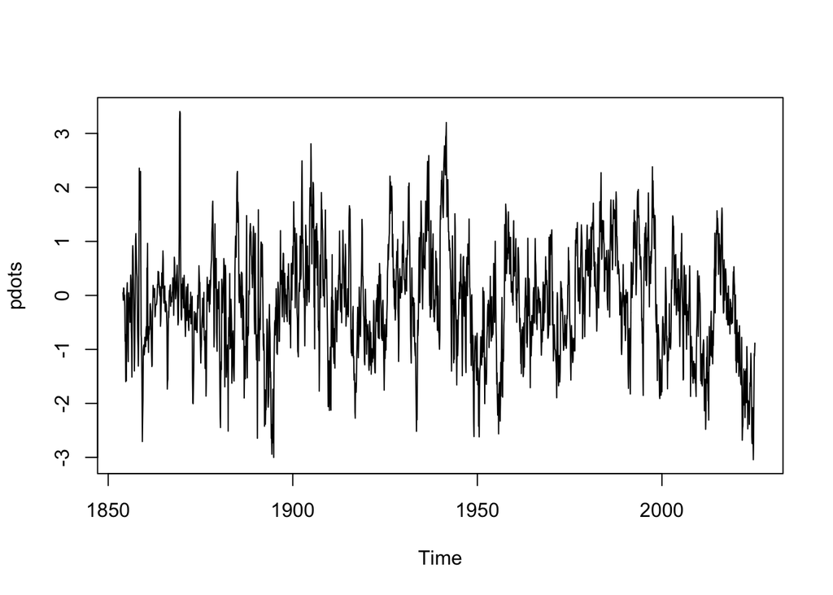

```r
pdots <- ts(np_climate_month$pdo, freq=12, start=c(np_climate_month$year[1], 1))
plot(pdots)
```

```r
library(atsalibrary)
data("np_climate")
# this has seasonal and annual averages
# use ?np_climate for info
colnames(np_climate_seasonal)
```

```
##  [1] "year"           "pna.fall"       "pna.spring"     "pna.summer"
##  [5] "pna.winter"     "pna.annual"     "epo.fall"       "epo.spring"
##  [9] "epo.summer"     "epo.winter"     "epo.annual"     "wp.fall"
## [13] "wp.spring"      "wp.summer"      "wp.winter"      "wp.annual"
## [17] "censo.fall"     "censo.spring"   "censo.summer"   "censo.winter"
## [21] "censo.annual"   "whwp.fall"      "whwp.spring"    "whwp.summer"
## [25] "whwp.winter"    "whwp.annual"    "oni.fall"       "oni.spring"
## [29] "oni.summer"     "oni.winter"     "oni.annual"     "meiv2.fall"
## [33] "meiv2.spring"   "meiv2.summer"   "meiv2.winter"   "meiv2.annual"
## [37] "pdo.fall"       "pdo.spring"     "pdo.summer"     "pdo.winter"
## [41] "pdo.annual"     "ipotpi.fall"    "ipotpi.spring"  "ipotpi.summer"
## [45] "ipotpi.winter"  "ipotpi.annual"  "np.fall"        "np.spring"
## [49] "np.summer"      "np.winter"      "np.annual"      "pacwarm.fall"
## [53] "pacwarm.spring" "pacwarm.summer" "pacwarm.winter" "pacwarm.annual"
## [57] "gmsst.fall"     "gmsst.spring"   "gmsst.summer"   "gmsst.winter"
## [61] "gmsst.annual"
```

## Prepping your covariates for `MARSS()`

You need a matrix:

- Columns = time and number of columns must match your data
- Rows = 1 row for each covariate

**Example for PDO**

Let’s say we want to use the April-June average PDO. We would construct a matrix with ncols being the years and 1 row for spring PDO.

```r
# col 1 is year
years <- which(np_climate_seasonal$year %in% 2000:2024)
spring_pdo <- np_climate_seasonal$pdo.spring[years]
cmat <- matrix(spring_pdo, nrow=1)
cmat
```

```
##            [,1]       [,2]   [,3]      [,4]  [,5]      [,6]       [,7]  [,8]
## [1,] -0.4936667 -0.8706667 -0.855 0.2236667 0.101 0.6923333 -0.1836667 -0.09
##           [,9]     [,10]      [,11]     [,12]  [,13]      [,14]     [,15]
## [1,] -1.490333 -1.181667 -0.2626667 -1.055333 -1.271 -0.6396667 0.4516667
##          [,16]    [,17] [,18]      [,19] [,20]  [,21] [,22]  [,23]     [,24]
## [1,] 0.6253333 1.264333 0.337 -0.5083333  0.22 -0.785 -1.57 -1.748 -2.190333
##          [,25]
## [1,] -2.347333
```

This is now $\mathbf{c}_t$ in
$$\mathbf{x}_t = \mathbf{x}_{t-1} + \mathbf{u} + \mathbf{C}\mathbf{c}_t +
\mathbf{w}_t$$

## Use PDO to predict steelhead returns

Idea is that pdo ($p_t$) is correlated with the fluctuations in log spawner returns ($x_t$).

$$x_t = x_{t-1} + u + (\alpha p_t + w_t)$$
But we have 4 steelhead time series for this example. We can write this as:
$$\begin{bmatrix}x_{1,t}\\x_{2,t}\\x_{3,t}\\x_{4,t}\end{bmatrix}=
\begin{bmatrix}x_{1,t-1}\\x_{2,t-1}\\x_{3,t-1}\\x_{4,t-1}\end{bmatrix} +
\begin{bmatrix}u_1\\u_2\\u_3\\u_4\end{bmatrix}+
\begin{bmatrix}\alpha_1\\\alpha_2\\\alpha_3\\\alpha_4\end{bmatrix} p_t +
\begin{bmatrix}w_1\\w_2\\w_3\\w_4\end{bmatrix}$$

What about the $w_t$’s? How are they related? Let’s say they are independent with unequal variances (the $x_t$ are diagonal and unequal). What about our observations? Let’s say each $y_t$ measures one $x_t$ with independent and equal error (R is diagonal and equal). Let’s fit this model with MARSS.

Wrangle the raw spawner data to get the $y_t$ for a MARSS model.

```r
library(tidyverse)
load("Data_Images/esa-salmon.rda")
esu <- unique(esa.salmon$esu_dps)
esunum <- which(esu == "Steelhead (Upper Columbia River DPS)")
esuname <- esu[esunum]

dat <- esa.salmon %>%
  subset(esu_dps == esuname) %>% # get only this ESU
  mutate(log.spawner = log(value)) %>% # create a column called log.spawner
  dplyr::select(esapopname, spawningyear, log.spawner) %>% # get just the columns that I need
  pivot_wider(names_from = "esapopname", values_from = "log.spawner") %>%
  column_to_rownames(var = "spawningyear") %>% # make the years rownames
  as.matrix() %>% # turn into a matrix with year down the rows
  t() # make time across the columns
# MARSS complains if I don't do this
dat[is.na(dat)] <- NA
# Clean up rownames
tmp <- rownames(dat)
tmp <- stringr::str_replace(tmp, "Steelhead [(]Upper Columbia River DPS[)]", "")
tmp <- stringr::str_replace(tmp, "River - summer", "")
tmp <- stringr::str_trim(tmp)
rownames(dat) <- tmp
```

Update your atsalibrary to version 1.6 to get the climate data or load `np_climate.RData` from the `Data_Images` directory.

```
install.packages('atsalibrary', repos = c('https://atsa-es.r-universe.dev', 'https://cloud.r-project.org'))
```

We will use spring PDO (Apr-Jun).

```r
library(atsalibrary)
data("np_climate")
years <- which(np_climate_seasonal$year %in% colnames(dat))
spring_pdo <- np_climate_seasonal$pdo.spring[years]
cmat <- matrix(spring_pdo, nrow=1)
# No NAs allowed. Interpolate if needed
any(is.na(cmat))
```

```
## [1] FALSE
```

Check that `cmat` and `dat` have the same number of columns (years).

```r
dim(cmat)
```

```
## [1]  1 63
```

```r
dim(dat)
```

```
## [1]  4 63
```

Specify a model

```r
# pdo
mod.list1 <- list(
  U = "unequal",
  R = "diagonal and equal",
  Q = "diagonal and unequal",
  c = cmat,
  C = "unequal"
)

# no pdo
mod.list2 <- list(
  U = "unequal",
  R = "diagonal and equal",
  Q = "diagonal and unequal")
```

```r
library(MARSS)
fit1 <- MARSS(dat, model=mod.list1)
```

```
## Success! abstol and log-log tests passed at 278 iterations.
## Alert: conv.test.slope.tol is 0.5.
## Test with smaller values (<0.1) to ensure convergence.
##
## MARSS fit is
## Estimation method: kem
## Convergence test: conv.test.slope.tol = 0.5, abstol = 0.001
## Estimation converged in 278 iterations.
## Log-likelihood: -153.0968
## AIC: 340.1936   AICc: 344.3569
##
##                             Estimate
## R.diag                       0.09599
## U.X.Entiat                  -0.00450
## U.X.Methow                  -0.00616
## U.X.Okanogan                -0.03111
## U.X.Wenatchee               -0.01993
## Q.(X.Entiat,X.Entiat)        0.12438
## Q.(X.Methow,X.Methow)        0.13116
## Q.(X.Okanogan,X.Okanogan)    0.11505
## Q.(X.Wenatchee,X.Wenatchee)  0.36533
## x0.X.Entiat                  5.52606
## x0.X.Methow                  7.33549
## x0.X.Okanogan                7.45314
## x0.X.Wenatchee               8.12444
## C.X.Entiat                  -0.07523
## C.X.Methow                  -0.02873
## C.X.Okanogan                -0.08870
## C.X.Wenatchee                0.05881
## Initial states (x0) defined at t=0
##
## Standard errors have not been calculated.
## Use MARSSparamCIs to compute CIs and bias estimates.
```

```r
fit2 <- MARSS(dat, model=mod.list2)
```

```
## Success! abstol and log-log tests passed at 304 iterations.
## Alert: conv.test.slope.tol is 0.5.
## Test with smaller values (<0.1) to ensure convergence.
##
## MARSS fit is
## Estimation method: kem
## Convergence test: conv.test.slope.tol = 0.5, abstol = 0.001
## Estimation converged in 304 iterations.
## Log-likelihood: -154.5953
## AIC: 335.1906   AICc: 337.6012
##
##                             Estimate
## R.diag                       0.08492
## U.X.Entiat                   0.00213
## U.X.Methow                  -0.00557
## U.X.Okanogan                -0.00920
## U.X.Wenatchee               -0.02427
## Q.(X.Entiat,X.Entiat)        0.14095
## Q.(X.Methow,X.Methow)        0.14800
## Q.(X.Okanogan,X.Okanogan)    0.14483
## Q.(X.Wenatchee,X.Wenatchee)  0.38490
## x0.X.Entiat                  5.57099
## x0.X.Methow                  7.40887
## x0.X.Okanogan                7.10616
## x0.X.Wenatchee               8.06274
## Initial states (x0) defined at t=0
##
## Standard errors have not been calculated.
## Use MARSSparamCIs to compute CIs and bias estimates.
```

Which one fits better based on AIC? The model without PDO is better (lower AICc).

```r
fit1$AICc
```

```
## [1] 344.3569
```

```r
fit2$AICc
```

```
## [1] 337.6012
```

## Resources

Chapter 7 MARSS models. ATSA Lab Book. https://atsa-es.github.io/atsa-labs/chap-mss.html

Chapter 8 MARSS models with covariates. ATSA Lab Book. https://atsa-es.github.io/atsa-labs/chap-msscov.html

Chapter 16 Modeling cyclic sockeye https://atsa-es.github.io/atsa-labs/chap-cyclic-sockeye.html